# 431 Class 05

Thomas E. Love, Ph.D.

2024-09-10

## Today’s Agenda

- An introduction to the `dm464` study
- Estimating the Difference between Two Population Means
  - using paired samples
  - using independent samples
- Comparisons using
  - ordinary least squares linear models (and their t-based equivalents),
  - the bootstrap, and
  - Bayesian linear models
- Most of the material in these slides is also discussed in Chapters 5-6 of [our course book](https://thomaselove.github.io/431-book/).

## Load packages and set theme

```r
library(janitor)

library(ggdist)     ## new today
library(knitr)      ## new (sort of) today
library(kableExtra) ## new today
library(MKinfer)    ## new today

library(patchwork)
library(rstanarm)
library(easystats)
library(tidyverse)

theme_set(theme_bw())
knitr::opts_chunk$set(comment = NA)

source("c05/data/Love-431.R") # for the lovedist() function
```

# Managing the Data

## Today’s data (`dm464_class05.csv`)

The data describe a cohort of 464 adults with diabetes, measured at baseline, and then two years later.

```r
dm5 <- read_csv("c05/data/dm464_class05.csv", show_col_types = FALSE)

names(dm5)
```

```
[1] "ID.Code"   "AGE"       "sex"       "Statin"    "RESIDENCE" "A1c Base"
[7] "A1c-End"   "LDLBase"
```

```r
dm5 <- janitor::clean_names(dm5)

names(dm5)
```

```
[1] "id_code"   "age"       "sex"       "statin"    "residence" "a1c_base"
[7] "a1c_end"   "ldl_base"
```

```r
dim(dm5)
```

```
[1] 464   8
```

## Variable Definitions

Cohort study where 464 adult subjects (ages 21-75) with a diabetes diagnosis were measured during a 12-month baseline period, and then again two years later.

| Variable | Definition |
| --- | --- |
| `id_code` | Subject Code (unique for each subject/row) |
| `age` | Age at end of the baseline period, in years |
| `sex` | Female or Male |
| `statin` | Statin prescription in baseline period: 1 (yes) or 0 (no) |
| `residence` | place of residence in baseline: City or Suburbs |
| `a1c_base` | baseline Hemoglobin A1c, % |
| `a1c_end` | most recent Hemoglobin A1c at end of study, % |
| `ldl_base` | baseline LDL cholesterol, mg/dl |

## Convert Characters to Factors

```r
dm5 <- dm5 |>
  mutate(across(where(is.character), as_factor)) |>
  mutate(id_code = as.character(id_code))

dm5 |> tail() # final six observations
```

```
# A tibble: 6 × 8
  id_code   age sex    statin residence a1c_base a1c_end ldl_base
  <chr>   <dbl> <fct>   <dbl> <fct>        <dbl>   <dbl>    <dbl>
1 DM-9916    48 Male        1 City           6       6.2      140
2 DM-9926    67 Female      1 City           6.3    12.7       90
3 DM-9930    62 Male        0 Suburbs        6.1     6         88
4 DM-9932    50 Male        0 Suburbs        7.6     7.8       96
5 DM-9936    61 Female      0 City           6.5     8        144
6 DM-9938    66 Male        1 City           7.1     7.4       81
```

- We might convert `statin` (1/0) to a binary factor, but I won’t, at least for now.

## Automated “Codebook”

- Why am I leaving out the `id_code` results here?
- This is most useful for missingness and range checks.

```r
data_codebook(dm5 |> select(-id_code))
```

```
select(dm5, -id_code) (464 rows and 7 variables, 7 shown)

ID | Name      | Type        | Missings |      Values |           N
---+-----------+-------------+----------+-------------+------------
1  | age       | numeric     | 0 (0.0%) |    [21, 73] |         464
---+-----------+-------------+----------+-------------+------------
2  | sex       | categorical | 0 (0.0%) |      Female | 288 (62.1%)
   |           |             |          |        Male | 176 (37.9%)
---+-----------+-------------+----------+-------------+------------
3  | statin    | numeric     | 0 (0.0%) |           0 |  97 (20.9%)
   |           |             |          |           1 | 367 (79.1%)
---+-----------+-------------+----------+-------------+------------
4  | residence | categorical | 0 (0.0%) |        City | 357 (76.9%)
   |           |             |          |     Suburbs | 107 (23.1%)
---+-----------+-------------+----------+-------------+------------
5  | a1c_base  | numeric     | 0 (0.0%) | [4.2, 14.9] |         464
---+-----------+-------------+----------+-------------+------------
6  | a1c_end   | numeric     | 0 (0.0%) |   [4.4, 17] |         464
---+-----------+-------------+----------+-------------+------------
7  | ldl_base  | numeric     | 0 (0.0%) |   [40, 231] |         464
-------------------------------------------------------------------
```

## Today’s Analytic Questions

1. How large is the difference in the mean Hemoglobin A1c level at baseline as compared to the A1c level in the follow-up period?
2. How large is the difference in baseline LDL for patients who do have a statin prescription at baseline compared to those who don’t have a statin prescription?

# Compare the Hemoglobin A1c level at baseline to the A1c level in the follow-up period.

## Comparing `a1c_base` to `a1c_end`

We are comparing each subject’s `a1c_base` to their `a1c_end`, to learn something about the mean of those differences.

Does this planned analysis make use of paired samples or independent samples?

- Each subject provides an `a1c_base` as well as an `a1c_end`.
- Calculating the difference (`a1c_end` - `a1c_base`) makes sense for each individual subject.
- This will leave us with $n = 464$ paired differences to study.

## Build the paired differences in A1c

```r
dm5 <- dm5 |>
  mutate(a1c_diff = a1c_end - a1c_base)

fivenum(dm5$a1c_diff) ## min, q25, median, q75, max
```

```
[1] -5.9 -0.5  0.2  1.1  8.9
```

```r
stem(dm5$a1c_diff)    ## stem-and-leaf display
```

```
  The decimal point is at the |

  -5 | 9
  -4 | 620
  -3 | 88753320000
  -2 | 887765554333332222211000
  -1 | 99988887776655555544444444333322222222211111110000000
  -0 | 99998888777777666666555555555555544444443333333333333332222222222221
   0 | 00000000001111111111111111111111111111222222222222222222222222223333+86
   1 | 0000000001111111122222222223333333333344444555555555566777788899
   2 | 000001112222333445555666677779
   3 | 0002346667778999
   4 | 112233699
   5 | 019
   6 | 04
   7 | 88
   8 | 9
```

## What does the distribution of A1c differences look like? (1/4)

- Plot `p1` - Histogram with superimposed Normal curve

```r
bw = 1 # specify width of bins in histogram

p1 <- ggplot(dm5, aes(x = a1c_diff)) +
  geom_histogram(binwidth = bw, fill = "black", col = "yellow") +
  stat_function(fun = function(x)
    dnorm(x, mean = mean(dm5$a1c_diff, na.rm = TRUE),
          sd = sd(dm5$a1c_diff, na.rm = TRUE)) *
          length(dm5$a1c_diff) * bw,
    geom = "area", alpha = 0.5,
    fill = "lightblue", col = "blue") +
  labs(x = "A1c difference (%)", y = "Count",
       title = "Histogram & Normal Curve")
```

## What does the distribution of A1c differences look like? (2/4)

- Plot `p2` - Normal Q-Q plot

```r
p2 <- ggplot(dm5, aes(sample = a1c_diff)) +
  geom_qq() + geom_qq_line(col = "red") +
  labs(y = "A1c difference (%)", x = "Standard Normal Distribution",
    title = "Normal Q-Q plot")
```

## What does the distribution of A1c differences look like? (3/4)

- Plot `p3` - Boxplot with violin and mean

```r
p3 <- ggplot(dm5, aes(x = a1c_diff, y = "")) +
  geom_violin(fill = "cornsilk") +
  geom_boxplot(width = 0.2) +
  stat_summary(fun = mean, geom = "point", shape = 16, col = "red") +
  labs(y = "", x = "A1c difference (%)", title = "Boxplot with Violin")
```

## Shape of the distribution? (4/4)

- Use the patchwork package to combine plots `p1`, `p2` and `p3` into a single figure
- See [section 2.4.6 in our Course Book](https://thomaselove.github.io/431-book/02_viz.html#three-plots-at-once) for similar “Three Plots At Once” code.

```r
p1 +
  (p2 / p3 + plot_layout(heights = c(2, 1))) +
  plot_annotation(title = "dm5 study: Differences in A1c")
```

## Shape of the distribution? (4/4)

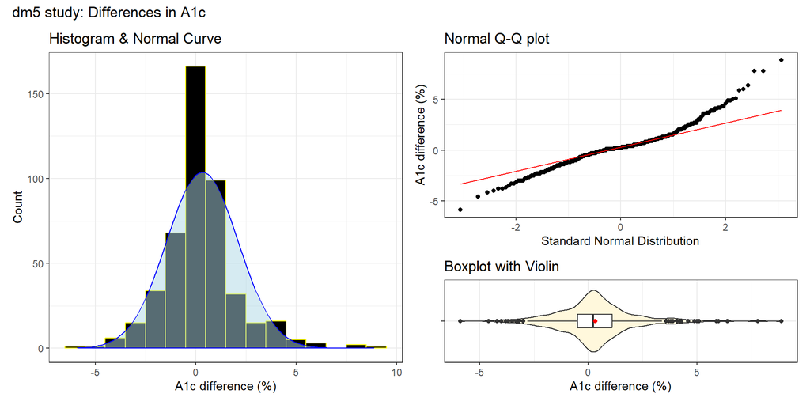

## Summaries of A1c differences

OK, so the distribution of A1c differences looks symmetric, but outlier-prone relative to a Normal distribution.

- Can we get some numerical summaries?

```r
dm5 |> reframe(lovedist(a1c_diff)) |>
  kbl(digits = 2) |>
  kable_styling(font_size = 32)
```

| n | miss | mean | sd | med | mad | min | q25 | q75 | max |
| --- | --- | --- | --- | --- | --- | --- | --- | --- | --- |
| 464 | 0 | 0.33 | 1.79 | 0.2 | 1.19 | -5.9 | -0.5 | 1.1 | 8.9 |

- What does the mean (0.33) mean in this context?

## Are our paired A1c values correlated?

- One way to see if pairing helps is to look for a positive correlation between the A1c values at the start (`a1c_base`) and at the end (`a1c_end`) of the study.

```r
cor(dm5$a1c_base, dm5$a1c_end)
```

```
[1] 0.5965358
```

- Here, we see a meaningful and positive correlation between the paired A1c values, suggesting that the pairing helped to reduce nuisance variation.

## Estimating the Mean Difference

We’ll demonstrate three approaches today (see [Chapter 5](https://thomaselove.github.io/431-book/05_paired.html)) for these paired samples.

1. Ordinary least squares regression model (equivalent to a paired t procedure in this setting) fit with `lm()`.
2. Bayesian regression model with a weakly informative prior.
3. Bootstrap confidence interval for the mean difference.

In each case, we’ll estimate the mean difference and form a **90%** uncertainty interval.

## Using `lm()` to fit an OLS model

```r
fit1 <- lm(a1c_diff ~ 1, data = dm5)

model_parameters(fit1, ci = 0.90)
```

```
Parameter   | Coefficient |   SE |       90% CI | t(463) |      p
-----------------------------------------------------------------
(Intercept) |        0.33 | 0.08 | [0.20, 0.47] |   4.00 | < .001
```

- Sample mean difference is 0.33, with 90% uncertainty interval (0.20, 0.47).
- All three of these summaries are positive numbers. What does that indicate?

## Paired t approach = same as OLS

- Note that here we must include `conf.level = 0.90` within the `t.test()` command and `ci = 0.90` in the call to `model_parameters()` in order to get the right (90%) uncertainty interval.

```r
fit2 <- t.test(dm5$a1c_diff, conf.level = 0.90)
model_parameters(fit2, ci = 0.90)
```

```
One Sample t-test

Parameter    | Mean |   mu | Difference |       90% CI | t(463) |      p
------------------------------------------------------------------------
dm5$a1c_diff | 0.33 | 0.00 |       0.33 | [0.20, 0.47] |   4.00 | < .001

Alternative hypothesis: true mean is not equal to 0
```

## Bayesian fit

Bayesian inference is an excellent choice for virtually every regression model, even when using **weakly informative default priors** (as we will do in 431), because it yields estimates which are stable, and because it helps us present the uncertainty associated with our estimates in useful ways.

```r
set.seed(431123)

fit3 <- stan_glm(a1c_diff ~ 1, data = dm5, refresh = 0)

model_parameters(fit3, ci = 0.90)
```

```
Parameter   | Median |       90% CI |   pd |  Rhat |     ESS |                 Prior
------------------------------------------------------------------------------------
(Intercept) |   0.33 | [0.19, 0.47] | 100% | 1.002 | 2431.00 | Normal (0.33 +- 4.46)
```

## The bootstrap (with `MKinfer`)

```r
set.seed(20240910)
boot.t.test(dm5$a1c_diff, conf.level = 0.90, R = 2000)
```

```
    Bootstrap One Sample t-test

data:  dm5$a1c_diff
number of bootstrap samples:  2000
bootstrap p-value < 5e-04
bootstrap mean of x (SE) = 0.3315159 (0.08268618)
90 percent bootstrap percentile confidence interval:
 0.1952586 0.4692349

Results without bootstrap:
t = 4.0016, df = 463, p-value = 7.323e-05
alternative hypothesis: true mean is not equal to 0
90 percent confidence interval:
 0.1950719 0.4682901
sample estimates:
mean of x
 0.331681
```

## 90% Uncertainty Intervals

Let’s consider the approaches we have demonstrated to estimate the mean of the paired differences in Hemoglobin A1c levels from the start to the end of the study…

| Approach | Estimate & 90% Interval |
| --- | --- |
| Ordinary least squares / Paired t | 0.33 (0.20, 0.47) |
| Bayesian fit with `stan_glm()` | 0.33 (0.19, 0.47) |
| Bootstrap (via `boot.t.test`) | 0.33 (0.20, 0.47) |

- Do our conclusions change here?

# Compare the baseline LDL for patients who do have a statin prescription at baseline to those who don’t.

## Comparing `ldl_base` by `statin` level

```r
ggplot(dm5, aes(x = ldl_base, y = statin)) +
  geom_violin() +
  geom_boxplot(width = 0.3)
```

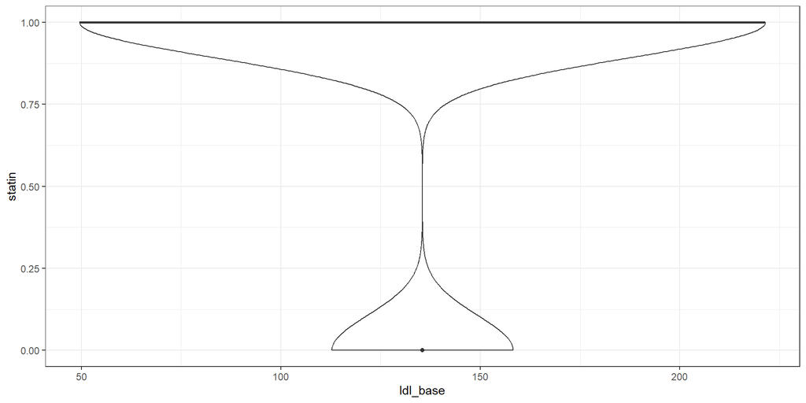

## Create a `statin` factor variable

```r
dm5 <- dm5 |>
  mutate(statin_f = as_factor(statin),
         statin_f = fct_recode(statin_f,
                               "Statin" = "1", "No Statin" = "0"))

dm5 |> tabyl(statin, statin_f)
```

```
 statin No Statin Statin
      0        97      0
      1         0    367
```

## Comparing `ldl_base` by `statin` level

We’ll build a boxplot, including violins and means.

```r
ggplot(dm5, aes(x = ldl_base, y = statin_f,
                fill = statin_f)) +
  geom_violin() +
  geom_boxplot(width = 0.3, fill = "white") +
  stat_summary(fun = mean, geom = "point", shape = 16, size = 3,
               col = "red") +
  scale_fill_viridis_d(alpha = 0.3) +
  guides(fill = "none") +
  labs(title = "LDL by Statin Prescription Status",
       x = "Most recent LDL in the baseline period, in mg/dl",
       y = "Statin Prescription at end of baseline period")
```

## Comparing `ldl_base` by `statin` level

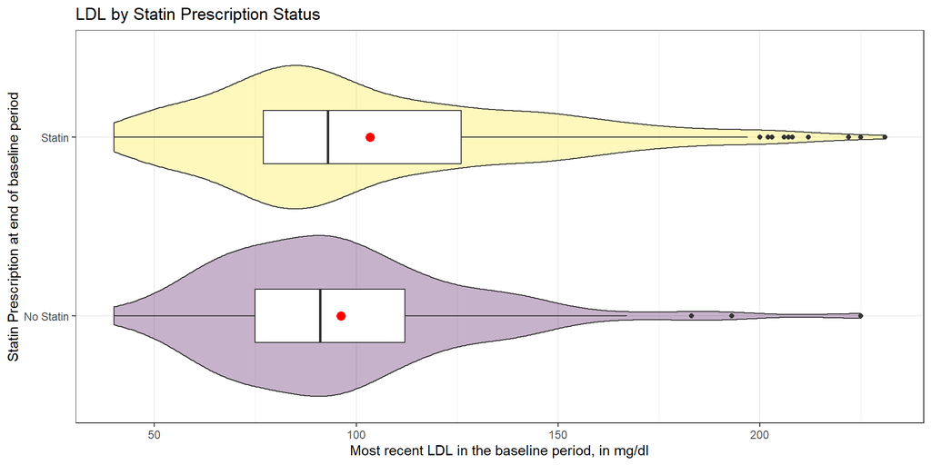

## Rain Cloud Plot

```r
ggplot(dm5, aes(y = statin_f, x = ldl_base, fill = statin_f)) +
  stat_slab(aes(thickness = after_stat(pdf * n)), scale = 0.7) +
  stat_dotsinterval(side = "bottom", scale = 0.7,
                    slab_linewidth = NA) +
  scale_fill_viridis_d(alpha = 0.7) +
  guides(fill = "none") +
  labs(title = "LDL by Statin Prescription Status",
       x = "Most recent LDL in the baseline period, in mg/dl",
       y = "Statin Prescription at end of baseline period")
```

## Rain Cloud Plot

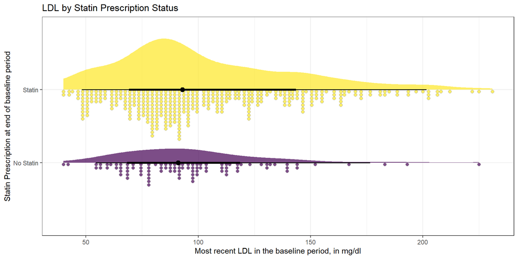

## Faceted Histograms

```r
bw = 5
ggplot(dm5, aes(x = ldl_base)) +
  geom_histogram(binwidth = bw, fill = "navy", col = "white") +
  facet_wrap(~ statin_f) +
  labs(x = "LDL at baseline", y = "Counts",
       title = "LDL by Statin Status")
```

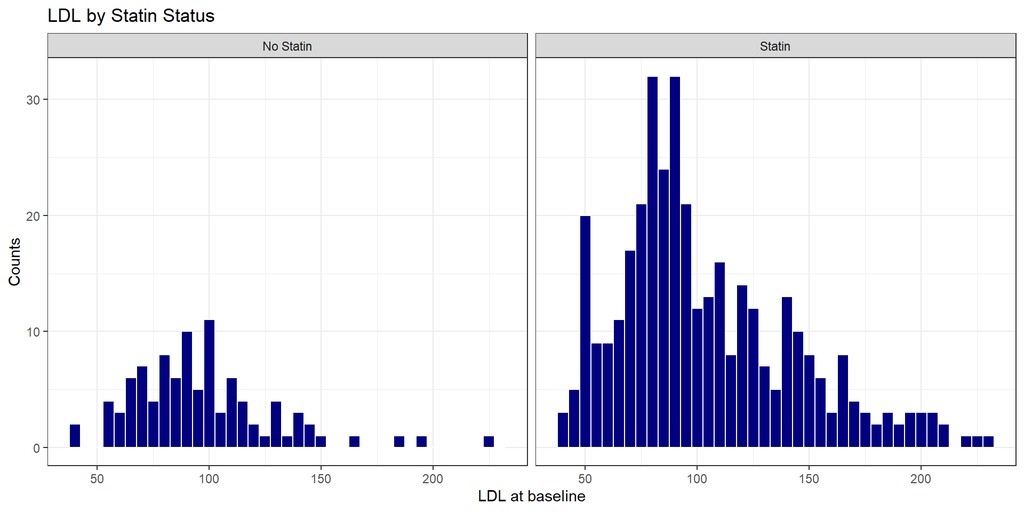

## Faceted Normal Q-Q plots

```r
ggplot(dm5, aes(sample = ldl_base)) +
  geom_qq() + geom_qq_line(col = "purple") +
  facet_wrap(~ statin_f) +
  labs(x = "Standard Normal distribution", y = "LDL at baseline")
```

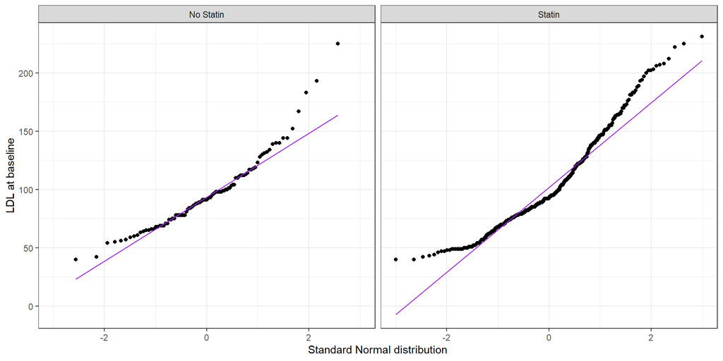

## Comparing `ldl_base` by `statin` level

- LDL data in each statin group are skewed to the right, with the mean higher than the median.

```r
dm5 |> group_by(statin_f) |> reframe(lovedist(ldl_base)) |>
  kbl(digits = 1) |> kable_styling(font_size = 32)
```

| statin_f | n | miss | mean | sd | med | mad | min | q25 | q75 | max |
| --- | --- | --- | --- | --- | --- | --- | --- | --- | --- | --- |
| No Statin | 97 | 0 | 96.3 | 31.6 | 91 | 28.2 | 40 | 75 | 112 | 225 |
| Statin | 367 | 0 | 103.4 | 39.5 | 93 | 34.1 | 40 | 77 | 126 | 231 |

- Were these data collected using matched/paired samples or using independent samples?

## Estimating the Difference in Means

We’ll demonstrate four approaches today (see [Chapter 6](https://thomaselove.github.io/431-book/06_twogroups.html)) for these independent samples.

1. Ordinary least squares regression model (which is the same as a pooled t procedure in this setting) fit with `lm()`.
2. Bayesian regression model with a weakly informative prior.
3. Welch t procedure without pooling the standard deviation across the two groups.
4. Bootstrap confidence interval for the difference in means.

Estimating difference in means with **90%** uncertainty interval.

## Using `lm()` to fit an OLS model

```r
fit4 <- lm(ldl_base ~ statin_f, data = dm5)

model_parameters(fit4, ci = 0.90)
```

```
Parameter         | Coefficient |   SE |          90% CI | t(462) |      p
--------------------------------------------------------------------------
(Intercept)       |       96.26 | 3.86 | [89.90, 102.62] |  24.94 | < .001
statin f [Statin] |        7.17 | 4.34 | [ 0.02,  14.32] |   1.65 | 0.099
```

- Comparing those on a statin to those that aren’t, our model suggests that the mean difference in LDL levels is 7.17 mg/dl with 90% uncertainty interval (0.02, 14.32) mg/dl.

## Pooled t approach = same as OLS

```r
fit5 <- t.test(ldl_base ~ statin_f, data = dm5,
               var.equal = TRUE, conf.level = 0.90)

model_parameters(fit5, ci = 0.90)
```

```
Two Sample t-test

Parameter |    Group | statin_f = No Statin | statin_f = Statin | Difference |          90% CI | t(462) |     p
---------------------------------------------------------------------------------------------------------------
ldl_base  | statin_f |                96.26 |            103.43 |      -7.17 | [-14.32, -0.02] |  -1.65 | 0.099

Alternative hypothesis: true difference in means between group No Statin and group Statin is not equal to 0
```

## Bayesian regression model

```r
set.seed(20240910)

fit6 <- stan_glm(ldl_base ~ statin_f, data = dm5, refresh = 0)

model_parameters(fit6, ci = 0.90)
```

```
Parameter      | Median |          90% CI |     pd |  Rhat |     ESS |                    Prior
-----------------------------------------------------------------------------------------------
(Intercept)    |  96.14 | [89.75, 102.50] |   100% | 1.000 | 3994.00 | Normal (101.93 +- 95.20)
statin_fStatin |   7.22 | [-0.06,  14.56] | 94.85% | 0.999 | 3765.00 |  Normal (0.00 +- 233.87)
```

## Welch t approach (no pooling)

```r
fit7 <- t.test(ldl_base ~ statin_f, data = dm5,
               var.equal = FALSE, conf.level = 0.90)

model_parameters(fit7, ci = 0.90)
```

```
Welch Two Sample t-test

Parameter |    Group | statin_f = No Statin | statin_f = Statin | Difference |          90% CI | t(183.36) |     p
------------------------------------------------------------------------------------------------------------------
ldl_base  | statin_f |                96.26 |            103.43 |      -7.17 | [-13.48, -0.86] |     -1.88 | 0.062

Alternative hypothesis: true difference in means between group No Statin and group Statin is not equal to 0
```

## Bootstrap, with `MKinfer`

```r
set.seed(431022)
boot.t.test(ldl_base ~ statin_f, var.equal = TRUE, R = 2000,
  data = dm5, conf.level = 0.90)
```

```
    Bootstrap Two Sample t-test

data:  ldl_base by statin_f
number of bootstrap samples:  2000
bootstrap p-value = 0.094
bootstrap difference of means (SE) = -7.208243 (4.343016)
90 percent bootstrap percentile confidence interval:
 -14.286936  -0.341577

Results without bootstrap:
t = -1.6523, df = 462, p-value = 0.09915
alternative hypothesis: true difference in means is not equal to 0
90 percent confidence interval:
 -14.32216921  -0.01795271
sample estimates:
mean in group No Statin    mean in group Statin
               96.25773               103.42779
```

## Bootstrap without pooling sd

```r
set.seed(431023)
boot.t.test(ldl_base ~ statin_f, var.equal = FALSE, R = 2000,
  data = dm5, conf.level = 0.90)
```

```
    Bootstrap Welch Two Sample t-test

data:  ldl_base by statin_f
number of bootstrap samples:  2000
bootstrap p-value = 0.096
bootstrap difference of means (SE) = -7.230676 (3.798356)
90 percent bootstrap percentile confidence interval:
 -13.6630903  -0.8817706

Results without bootstrap:
t = -1.8786, df = 183.36, p-value = 0.06188
alternative hypothesis: true difference in means is not equal to 0
90 percent confidence interval:
 -13.4797701  -0.8603518
sample estimates:
mean in group No Statin    mean in group Statin
               96.25773               103.42779
```

## 90% Uncertainty Intervals

Estimating the mean difference in LDL levels at baseline for the “Statin” group minus the “No Statin” group…

| Approach | Estimate & 90% Interval |
| --- | --- |
| Ordinary least squares / Pooled t | 7.17 (0.02, 14.32) |
| Bayesian fit with `stan_glm()` | 7.22 (-0.06, 14.56) |
| Welch t without pooling sd | 7.17 (0.86, 13.48) |
| Bootstrap with pooled sd | 7.21 (0.34, 14.29) |
| Bootstrap with unpooled sd | 7.23 (0.88, 13.66) |

- Do our conclusions change here?

## Repeating Today’s Agenda

- An introduction to the `dm464` study
- Estimating the Difference between Two Population Means
  - using paired samples
  - using independent samples
- Comparisons using
  - ordinary least squares linear models,
  - the bootstrap, and
  - Bayesian linear models
- For more examples, see Chapters 5-6 of [our course book](https://thomaselove.github.io/431-book/).
- At this point, you should be able to do [Lab 2](https://github.com/THOMASELOVE/431-labs-2024/tree/main/lab2).

[figure not shown]

431 Class 05 | 2024-09-10 | https://thomaselove.github.io/431-2024/